$$ \newcommand{\mat}[1]{\boldsymbol {#1}} \newcommand{\mattr}[1]{\boldsymbol {#1}^\top} \newcommand{\matinv}[1]{\boldsymbol {#1}^{-1}} \newcommand{\vec}[1]{\boldsymbol {#1}} \newcommand{\vectr}[1]{\boldsymbol {#1}^\top} \newcommand{\rvar}[1]{\mathrm {#1}} \newcommand{\rvec}[1]{\boldsymbol{\mathrm{#1}}} \newcommand{\diag}{\mathop{\mathrm {diag}}} \newcommand{\set}[1]{\mathbb {#1}} \newcommand{\norm}[1]{\left\lVert#1\right\rVert} \newcommand{\pderiv}[2]{\frac{\partial #1}{\partial #2}} \newcommand{\bb}[1]{\boldsymbol{#1}} $$

# Part 2: Optimization and Training

In this part we will learn how to implement optimization algorithms for deep networks. Additionally, we'll learn how to write training loops and implement a modular model trainer. We'll use our optimizers and training code to test a few configurations for classifying images with an MLP model.

```python
import os
import numpy as np
import matplotlib.pyplot as plt
import unittest
import torch
import torchvision
import torchvision.transforms as tvtf

%matplotlib inline
%load_ext autoreload
%autoreload 2

seed = 42

plt.rcParams.update({'font.size': 12})
test = unittest.TestCase()
```

```
The autoreload extension is already loaded. To reload it, use:
  %reload_ext autoreload
```

## Implementing Optimization Algorithms

In the context of deep learning, an optimization algorithm is some method of iteratively updating model parameters so that the loss converges toward some local minimum (which we hope will be good enough).

Gradient descent-based methods are by far the most popular algorithms for optimization of neural network parameters. However the high-dimensional loss-surfaces we encounter in deep learning applications are highly non-convex. They may be riddled with local minima, saddle points, large plateaus and a host of very challenging "terrain" for gradient-based optimization. This gave rise to many different methods of performing the parameter updates based on the loss gradients, aiming to tackle these optimization challenges.

The most basic gradient-based update rule can be written as,

$$ \vec{\theta} \leftarrow \vec{\theta} - \eta \nabla_{\vec{\theta}} L(\vec{\theta}; \mathcal{D}) $$

where $\mathcal{D} = \left\{ (\vec{x}^i, \vec{y}^i) \right\}_{i=1}^{M}$ is our training dataset or part of it. Specifically, if we have in total $N$ training samples, then

- If $M=N$ this is known as regular gradient descent. If the dataset does not fit in memory it becomes infeasible to compute.
- If $M=1$, the loss is computed w.r.t. a single different sample each time. This is known as stochastic gradient descent.
- If $1<M<N$ this is known as stochastic mini-batch gradient descent. This is the most commonly-used option.

The intuition behind gradient descent is simple: since the gradient of a multivariate function points to the direction of steepest ascent ("uphill"), we move in the opposite direction. A small step size $\eta$ known as the **learning rate** is required since, as with any derivative, the gradient's value is only accurate close to the point it was evaluated at (the current value of $\vec{\theta}$).

[figure not shown]

The idea behind the stochastic versions is that by constantly changing the samples we compute the loss with, we get a dynamic error surface, i.e. it's different for each set of training samples. This is thought to generally improve the optimization since it may help the optimizer get out of flat regions or sharp local minima since these features may disappear in the loss surface of subsequent batches. The image below illustrates this. The different lines are different 1-dimensional losses for different training set-samples.

[figure not shown]

All deep learning frameworks provide implementations of various gradient-based optimization algorithms. Here we'll implement our own optimization module from scratch, this time keeping a similar API to the PyTorch `optim` package.

We define a base `Optimizer` class. An optimizer holds a set of parameter tensors (these are the trainable parameters of some model) and maintains internal state. It may be used as follows:

- After the forward pass has been performed the optimizer's `zero_grad()` function is invoked to clear the parameter gradients computed by previous iterations.
- After the backward pass has been performed, and gradients have been calculated for these parameters, the optimizer's `step()` function is invoked in order to update the value of each parameter based on it's gradient.

The exact method of update is implementation-specific for each optimizer and may depend on it's internal state. In addition, adding the regularization penalty to the gradient is handled by the optimizer since it only depends on the parameter values (and not the data).

```python
import hw2.optimizers as optimizers
help(optimizers.Optimizer)
```

```
Help on class Optimizer in module hw2.optimizers:

class Optimizer(abc.ABC)
 |  Optimizer(params)
 |  Base class for optimizers.
 |  Method resolution order:
 |      Optimizer
 |      abc.ABC
 |      builtins.object
 |  Methods defined here:
 |  __init__(self, params)
 |      :param params: A sequence of model parameters to optimize. Can be a
 |      list of (param,grad) tuples as returned by the Blocks, or a list of
 |      pytorch tensors in which case the grad will be taken from them.
 |  step(self)
 |      Updates all the registered parameter values based on their gradients.
 |  zero_grad(self)
 |      Sets the gradient of the optimized parameters to zero (in place).
 |  ----------------------------------------------------------------------
 |  Data descriptors defined here:
 |  __dict__
 |      dictionary for instance variables (if defined)
 |  __weakref__
 |      list of weak references to the object (if defined)
 |  params
 |      :return: A sequence of parameter tuples, each tuple containing
 |      (param_data, param_grad). The data should be updated in-place
 |      according to the grad.
 |  ----------------------------------------------------------------------
 |  Data and other attributes defined here:
 |  __abstractmethods__ = frozenset({'step'})
```

## Vanilla SGD with Regularization

Let's start by implementing the simplest gradient based optimizer. The update rule will be exacly as stated above, but we'll also add a L2-regularization term to the gradient. Remember that in the **loss function**, the L2 regularization term is expressed by

$$R(\vec{\theta}) = \frac{1}{2}\lambda||\vec{\theta}||^2_2.$$

**TODO**: Complete the implementation of the `VanillaSGD` class in the `hw2/optimizers.py` module.

```python
# Test VanillaSGD
torch.manual_seed(42)
p = torch.randn(500, 10)
dp = torch.randn(*p.shape)*2
params = [(p, dp)]

vsgd = optimizers.VanillaSGD(params, learn_rate=0.5, reg=0.1)
vsgd.step()

expected_p = torch.load('tests/assets/expected_vsgd.pt')
diff = torch.norm(p-expected_p).item()
test.assertLess(diff, 1e-3)
```

## Training

Now that we can build a model and loss function, compute their gradients and we have an optimizer, we can finally do some training!

In the spirit of more modular software design, we'll implement a class that will aid us in automating the repetitive training loop code that we usually write over and over again. This will be useful for both training our `Block`-based models and also later for training PyTorch `nn.Module`s.

Here's our `Trainer` API:

```python
import hw2.training as training
help(training.Trainer)
```

```
Help on class Trainer in module hw2.training:

class Trainer(abc.ABC)
 |  Trainer(model, loss_fn, optimizer, device=None)
 |  A class abstracting the various tasks of training models.
 |  Provides methods at multiple levels of granularity:
 |  - Multiple epochs (fit)
 |  - Single epoch (train_epoch/test_epoch)
 |  - Single batch (train_batch/test_batch)
 |  Method resolution order:
 |      Trainer
 |      abc.ABC
 |      builtins.object
 |  Methods defined here:
 |  __init__(self, model, loss_fn, optimizer, device=None)
 |      Initialize the trainer.
 |      :param model: Instance of the model to train.
 |      :param loss_fn: The loss function to evaluate with.
 |      :param optimizer: The optimizer to train with.
 |      :param device: torch.device to run training on (CPU or GPU).
 |  fit(self, dl_train: torch.utils.data.dataloader.DataLoader, dl_test: torch.utils.data.dataloader.DataLoader, num_epochs, checkpoints: str = None, early_stopping: int = None, print_every=1, **kw) -> cs236605.train_results.FitResult
 |      Trains the model for multiple epochs with a given training set,
 |      and calculates validation loss over a given validation set.
 |      :param dl_train: Dataloader for the training set.
 |      :param dl_test: Dataloader for the test set.
 |      :param num_epochs: Number of epochs to train for.
 |      :param checkpoints: Whether to save model to file every time the
 |          test set accuracy improves. Should be a string containing a
 |          filename without extension.
 |      :param early_stopping: Whether to stop training early if there is no
 |          test loss improvement for this number of epochs.
 |      :param print_every: Print progress every this number of epochs.
 |      :return: A FitResult object containing train and test losses per epoch.
 |  test_batch(self, batch) -> cs236605.train_results.BatchResult
 |      Runs a single batch forward through the model and calculates loss.
 |      :param batch: A single batch of data  from a data loader (might
 |          be a tuple of data and labels or anything else depending on
 |          the underlying dataset.
 |      :return: A BatchResult containing the value of the loss function and
 |          the number of correctly classified samples in the batch.
```

[output cut: 12 more lines]

```
 |          the number of correctly classified samples in the batch.
 |  train_epoch(self, dl_train: torch.utils.data.dataloader.DataLoader, **kw) -> cs236605.train_results.EpochResult
 |      Train once over a training set (single epoch).
 |      :param dl_train: DataLoader for the training set.
 |      :param kw: Keyword args supported by _foreach_batch.
 |      :return: An EpochResult for the epoch.
 |  ----------------------------------------------------------------------
 |  Data descriptors defined here:
 |  __dict__
 |      dictionary for instance variables (if defined)
 |  __weakref__
 |      list of weak references to the object (if defined)
 |  ----------------------------------------------------------------------
 |  Data and other attributes defined here:
 |  __abstractmethods__ = frozenset({'test_batch', 'train_batch'})
```

The `Trainer` class splits the task of training (and evaluating) models into three conceptual levels,

- Multiple epochs - the `fit` method, which returns a `FitResult` containing losses and accuracies for all epochs.
- Single epoch - the `train_epoch` and `test_epoch` methods, which return an `EpochResult` containing losses per batch and the single accuracy result of the epoch.
- Single batch - the `train_batch` and `test_batch` methods, which return a `BatchResult` containing a single loss and the number of correctly classified samples in the batch.

It implements the first two levels. Inheriting classes are expected to implement the single-batch level methods since these are generally model/task specific.

The first thing we should do in order to verify our model, gradient calculations and optimizer implementation is to try to overfit a large model (many parameters) to a small dataset (few images). This will show us that things are working properly.

Let's begin by loading the CIFAR-10 dataset.

```python
data_dir = os.path.join(os.getenv('HOME'), '.pytorch-datasets')
ds_train = torchvision.datasets.CIFAR10(root=data_dir, download=True, train=True, transform=tvtf.ToTensor())
ds_test = torchvision.datasets.CIFAR10(root=data_dir, download=True, train=False, transform=tvtf.ToTensor())

print(f'Train: {len(ds_train)} samples')
print(f'Test: {len(ds_test)} samples')
```

```
Files already downloaded and verified
Files already downloaded and verified
Train: 50000 samples
Test: 10000 samples
```

Now, let's implement just a small part of our training logic since that's what we need right now.

**TODO**:

1. Complete the implementation of the `train_batch()` method in the `BlocksTrainer` class within the `hw2/training.py` module.
2. Update the hyperparameter values in the `part2_overfit_hp()` function in the `hw2/answers.py` module. Tweak the hyperparameter values until your model overfits a small number of samples in the block below. You should get 100% accuracy within a few epochs.

```python
import hw2.blocks as blocks
import hw2.models as models
import hw2.answers as answers
from torch.utils.data import DataLoader

# Overfit to a very small dataset of 20 samples
batch_size = 10
max_batches = 2
dl_train = torch.utils.data.DataLoader(ds_train, batch_size, shuffle=False)

# Get hyperparameters
hp = answers.part2_overfit_hp()

torch.manual_seed(seed)
model = models.MLP(3*32*32, num_classes=10, hidden_features=[128]*3, wstd=hp['wstd'])
loss_fn = blocks.CrossEntropyLoss()
optimizer = optimizers.VanillaSGD(model.params(), learn_rate=hp['lr'], reg=hp['reg'])

# Run training over small dataset multiple times
trainer = training.BlocksTrainer(model, loss_fn, optimizer)
best_acc = 0
for i in range(20):
    res = trainer.train_epoch(dl_train, max_batches=max_batches)
    best_acc = res.accuracy if res.accuracy > best_acc else best_acc

test.assertGreaterEqual(best_acc, 90)
```

```
train_batch (Avg. Loss 5.994, Accuracy 20.0): 100%|██████████| 2/2 [00:00<00:00, 27.87it/s]
train_batch (Avg. Loss 8.039, Accuracy 15.0): 100%|██████████| 2/2 [00:00<00:00, 70.43it/s]
train_batch (Avg. Loss 10.767, Accuracy 20.0): 100%|██████████| 2/2 [00:00<00:00, 70.02it/s]
train_batch (Avg. Loss 5.772, Accuracy 15.0): 100%|██████████| 2/2 [00:00<00:00, 69.90it/s]
train_batch (Avg. Loss 2.645, Accuracy 35.0): 100%|██████████| 2/2 [00:00<00:00, 69.53it/s]
train_batch (Avg. Loss 1.891, Accuracy 35.0): 100%|██████████| 2/2 [00:00<00:00, 69.53it/s]
train_batch (Avg. Loss 1.404, Accuracy 55.0): 100%|██████████| 2/2 [00:00<00:00, 68.65it/s]
train_batch (Avg. Loss 1.161, Accuracy 60.0): 100%|██████████| 2/2 [00:00<00:00, 68.37it/s]
train_batch (Avg. Loss 0.983, Accuracy 60.0): 100%|██████████| 2/2 [00:00<00:00, 68.52it/s]
train_batch (Avg. Loss 0.831, Accuracy 75.0): 100%|██████████| 2/2 [00:00<00:00, 68.48it/s]
train_batch (Avg. Loss 0.715, Accuracy 75.0): 100%|██████████| 2/2 [00:00<00:00, 67.96it/s]
train_batch (Avg. Loss 0.612, Accuracy 80.0): 100%|██████████| 2/2 [00:00<00:00, 68.48it/s]
train_batch (Avg. Loss 0.519, Accuracy 80.0): 100%|██████████| 2/2 [00:00<00:00, 65.36it/s]
train_batch (Avg. Loss 0.431, Accuracy 80.0): 100%|██████████| 2/2 [00:00<00:00, 68.69it/s]
train_batch (Avg. Loss 0.355, Accuracy 85.0): 100%|██████████| 2/2 [00:00<00:00, 68.58it/s]
train_batch (Avg. Loss 0.285, Accuracy 85.0): 100%|██████████| 2/2 [00:00<00:00, 91.07it/s]
train_batch (Avg. Loss 0.224, Accuracy 95.0): 100%|██████████| 2/2 [00:00<00:00, 92.84it/s]
train_batch (Avg. Loss 0.168, Accuracy 95.0): 100%|██████████| 2/2 [00:00<00:00, 94.13it/s]
train_batch (Avg. Loss 0.120, Accuracy 95.0): 100%|██████████| 2/2 [00:00<00:00, 95.63it/s]
train_batch (Avg. Loss 0.084, Accuracy 100.0): 100%|██████████| 2/2 [00:00<00:00, 72.33it/s]
```

Now that we know training works, let's try to fit a model to a bit more data for a few epochs, to see how well we're doing. First, we need some code to plot the FitResults object.

```python
from cs236605.plot import plot_fit
```

**TODO**:

1. Complete the implementation of the `test_batch()` method in the `BlocksTrainer` class within the `hw2/training.py` module.
2. Implement the `fit()` method of the `Trainer` class within the `hw2/training.py` module.
3. Tweak the hyperparameters for this section in the `part2_optim_hp()` function in the `hw2/answers.py` module.
4. Run the following blocks to train. Try to get above 35-40% test-set accuracy.

```python
# Define a larger part of the CIFAR-10 dataset (still not the whole thing)
batch_size = 50
max_batches = 100
in_features = 3*32*32
num_classes = 10
dl_train = torch.utils.data.DataLoader(ds_train, batch_size, shuffle=False)
dl_test = torch.utils.data.DataLoader(ds_test, batch_size//2, shuffle=False)
```

```python
# Define a function to train a model with our Trainer and various optimizers
def train_with_optimizer(opt_name, opt_class, fig):
    torch.manual_seed(seed)

    # Get hyperparameters
    hp = answers.part2_optim_hp()
    hidden_features = [128] * 5
    num_epochs = 10

    # Create model, loss and optimizer instances
    model = models.MLP(in_features, num_classes, hidden_features, wstd=hp['wstd'])
    loss_fn = blocks.CrossEntropyLoss()
    optimizer = opt_class(model.params(), learn_rate=hp[f'lr_{opt_name}'], reg=hp['reg'])

    # Train with the Trainer
    trainer = training.BlocksTrainer(model, loss_fn, optimizer)
    fit_res = trainer.fit(dl_train, dl_test, num_epochs, max_batches=max_batches)

    fig, axes = plot_fit(fit_res, fig=fig, legend=opt_name)
    return fig
```

```
--- EPOCH 1/10 ---
train_batch (Avg. Loss 2.021, Accuracy 27.8): 100%|██████████| 1000/1000 [00:21<00:00, 46.44it/s]
test_batch (Avg. Loss 1.915, Accuracy 30.7): 100%|██████████| 400/400 [00:03<00:00, 102.01it/s]
--- EPOCH 2/10 ---
train_batch (Avg. Loss 1.818, Accuracy 35.6): 100%|██████████| 1000/1000 [00:23<00:00, 48.07it/s]
test_batch (Avg. Loss 1.852, Accuracy 33.4): 100%|██████████| 400/400 [00:03<00:00, 115.86it/s]
--- EPOCH 3/10 ---
train_batch (Avg. Loss 1.761, Accuracy 37.5): 100%|██████████| 1000/1000 [00:21<00:00, 44.66it/s]
test_batch (Avg. Loss 1.807, Accuracy 34.4): 100%|██████████| 400/400 [00:03<00:00, 113.91it/s]
--- EPOCH 4/10 ---
train_batch (Avg. Loss 1.716, Accuracy 39.3): 100%|██████████| 1000/1000 [00:21<00:00, 45.05it/s]
test_batch (Avg. Loss 1.771, Accuracy 36.3): 100%|██████████| 400/400 [00:03<00:00, 110.81it/s]
--- EPOCH 5/10 ---
train_batch (Avg. Loss 1.686, Accuracy 40.5): 100%|██████████| 1000/1000 [00:22<00:00, 44.89it/s]
test_batch (Avg. Loss 1.743, Accuracy 37.9): 100%|██████████| 400/400 [00:03<00:00, 112.49it/s]
--- EPOCH 6/10 ---
train_batch (Avg. Loss 1.664, Accuracy 41.3): 100%|██████████| 1000/1000 [00:22<00:00, 45.06it/s]
test_batch (Avg. Loss 1.727, Accuracy 38.8): 100%|██████████| 400/400 [00:03<00:00, 113.31it/s]
--- EPOCH 7/10 ---
train_batch (Avg. Loss 1.649, Accuracy 42.1): 100%|██████████| 1000/1000 [00:21<00:00, 45.17it/s]
test_batch (Avg. Loss 1.719, Accuracy 39.4): 100%|██████████| 400/400 [00:03<00:00, 113.55it/s]
--- EPOCH 8/10 ---
train_batch (Avg. Loss 1.637, Accuracy 42.5): 100%|██████████| 1000/1000 [00:22<00:00, 46.41it/s]
test_batch (Avg. Loss 1.709, Accuracy 39.8): 100%|██████████| 400/400 [00:03<00:00, 114.74it/s]
--- EPOCH 9/10 ---
train_batch (Avg. Loss 1.626, Accuracy 42.9): 100%|██████████| 1000/1000 [00:22<00:00, 44.65it/s]
test_batch (Avg. Loss 1.698, Accuracy 40.2): 100%|██████████| 400/400 [00:03<00:00, 114.93it/s]
--- EPOCH 10/10 ---
train_batch (Avg. Loss 1.616, Accuracy 43.3): 100%|██████████| 1000/1000 [00:21<00:00, 47.12it/s]
test_batch (Avg. Loss 1.689, Accuracy 40.9): 100%|██████████| 400/400 [00:03<00:00, 112.38it/s]
```

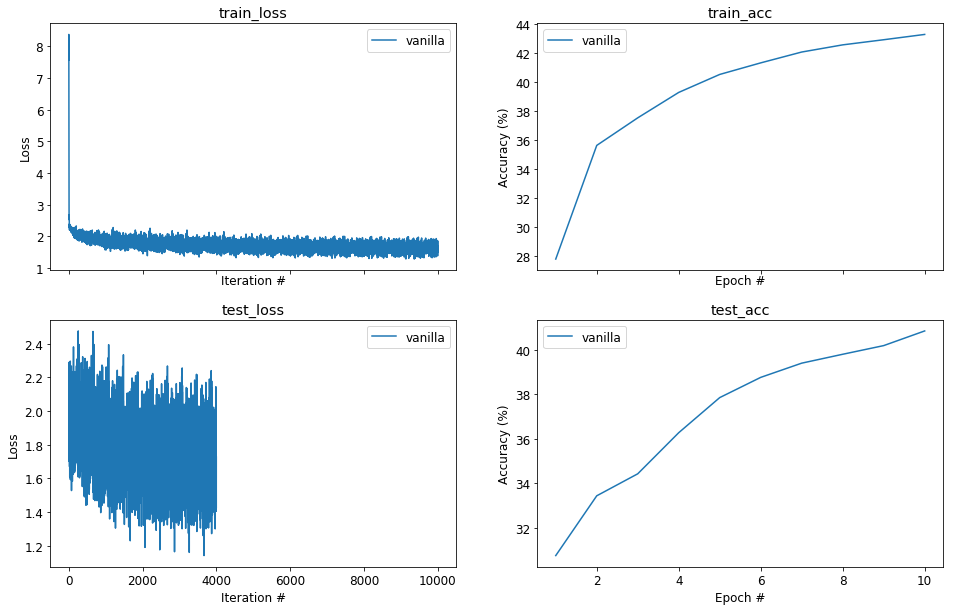

```python
fig_optim = None
fig_optim = train_with_optimizer('vanilla', optimizers.VanillaSGD, fig_optim)
```

## Momentum

The simple vanilla SGD update is rarely used in practice since it's very slow to converge relative to other optimization algorithms.

One reason is that naïvely updating in the direction of the current gradient causes it to fluctuate wildly in areas of the loss surface where some dimensions are much steeper than others. Another reason is that using the same learning rate for all parameters is not a great idea since not all parameters are created equal. For example, parameters associated with rare features should be updated with a larger step than ones associated with commonly-occurring features because they'll get less updates through the gradients.

Therefore more advanced optimizers take into account the previous gradients of a parameter and/or try to use a per-parameter specific learning rate instead of a common one.

Let's now implement a simple and common optimizer: SGD with Momentum. This optimizer takes **previous gradients** of a parameter into account when updating it's value instead of just the current one. In practice it usually provides faster convergence than the vanilla SGD.

The SGD with Momentum update rule can be stated as follows: $$\begin{align} \vec{v}_{t+1} &= \mu \vec{v}_t - \eta \delta \vec{\theta}_t \\ \vec{\theta}_{t+1} &= \vec{\theta}_t + \vec{v}_{t+1} \end{align}$$

Where $\eta$ is the learning rate, $\vec{\theta}$ is a model parameter, $\delta \vec{\theta}_t=\pderiv{L}{\vec{\theta}}(\vec{\theta}_t)$ is the gradient of the loss w.r.t. to the parameter and $\mu$ is a hyperparameter known as momentum.

Expanding the update rule recursively shows us now the parameter update infact depends on all previous gradient values for that parameter, where the old gradients are exponentially decayed by a factor of $\mu$ at each timestep.

Since we're incorporating previous gradient (update directions), a noisy value of the current gradient will have less effect so that the general direction of previous updates is maintained somewhat. The following figure illustrates this.

[figure not shown]

**TODO**:

1. Complete the implementation of the `MomentumSGD` class in the `hw2/optimizers.py` module.
2. Tweak the learning rate for momentum in `part2_optim_hp()` the function in the `hw2/answers.py` module.
3. Run the following block to compare to the vanilla SGD.

```
--- EPOCH 1/10 ---
train_batch (Avg. Loss 2.091, Accuracy 24.2): 100%|██████████| 1000/1000 [00:21<00:00, 46.24it/s]
test_batch (Avg. Loss 1.935, Accuracy 29.7): 100%|██████████| 400/400 [00:03<00:00, 113.10it/s]
--- EPOCH 2/10 ---
train_batch (Avg. Loss 1.898, Accuracy 32.2): 100%|██████████| 1000/1000 [00:22<00:00, 40.07it/s]
test_batch (Avg. Loss 1.870, Accuracy 32.3): 100%|██████████| 400/400 [00:04<00:00, 99.39it/s]
--- EPOCH 3/10 ---
train_batch (Avg. Loss 1.850, Accuracy 34.0): 100%|██████████| 1000/1000 [00:21<00:00, 45.37it/s]
test_batch (Avg. Loss 1.830, Accuracy 33.9): 100%|██████████| 400/400 [00:03<00:00, 113.29it/s]
--- EPOCH 4/10 ---
train_batch (Avg. Loss 1.818, Accuracy 35.0): 100%|██████████| 1000/1000 [00:21<00:00, 45.12it/s]
test_batch (Avg. Loss 1.803, Accuracy 35.0): 100%|██████████| 400/400 [00:03<00:00, 116.72it/s]
--- EPOCH 5/10 ---
train_batch (Avg. Loss 1.794, Accuracy 36.0): 100%|██████████| 1000/1000 [00:21<00:00, 47.93it/s]
test_batch (Avg. Loss 1.784, Accuracy 35.6): 100%|██████████| 400/400 [00:03<00:00, 109.50it/s]
--- EPOCH 6/10 ---
train_batch (Avg. Loss 1.775, Accuracy 36.7): 100%|██████████| 1000/1000 [00:21<00:00, 44.90it/s]
test_batch (Avg. Loss 1.768, Accuracy 36.4): 100%|██████████| 400/400 [00:03<00:00, 111.34it/s]
--- EPOCH 7/10 ---
train_batch (Avg. Loss 1.758, Accuracy 37.3): 100%|██████████| 1000/1000 [00:22<00:00, 44.11it/s]
test_batch (Avg. Loss 1.754, Accuracy 36.9): 100%|██████████| 400/400 [00:03<00:00, 110.73it/s]
--- EPOCH 8/10 ---
train_batch (Avg. Loss 1.742, Accuracy 37.9): 100%|██████████| 1000/1000 [00:22<00:00, 45.07it/s]
test_batch (Avg. Loss 1.742, Accuracy 37.3): 100%|██████████| 400/400 [00:03<00:00, 112.99it/s]
--- EPOCH 9/10 ---
train_batch (Avg. Loss 1.730, Accuracy 38.6): 100%|██████████| 1000/1000 [00:22<00:00, 44.80it/s]
test_batch (Avg. Loss 1.734, Accuracy 37.9): 100%|██████████| 400/400 [00:03<00:00, 103.16it/s]
--- EPOCH 10/10 ---
train_batch (Avg. Loss 1.719, Accuracy 38.9): 100%|██████████| 1000/1000 [00:22<00:00, 45.00it/s]
test_batch (Avg. Loss 1.725, Accuracy 38.4): 100%|██████████| 400/400 [00:03<00:00, 112.00it/s]
```

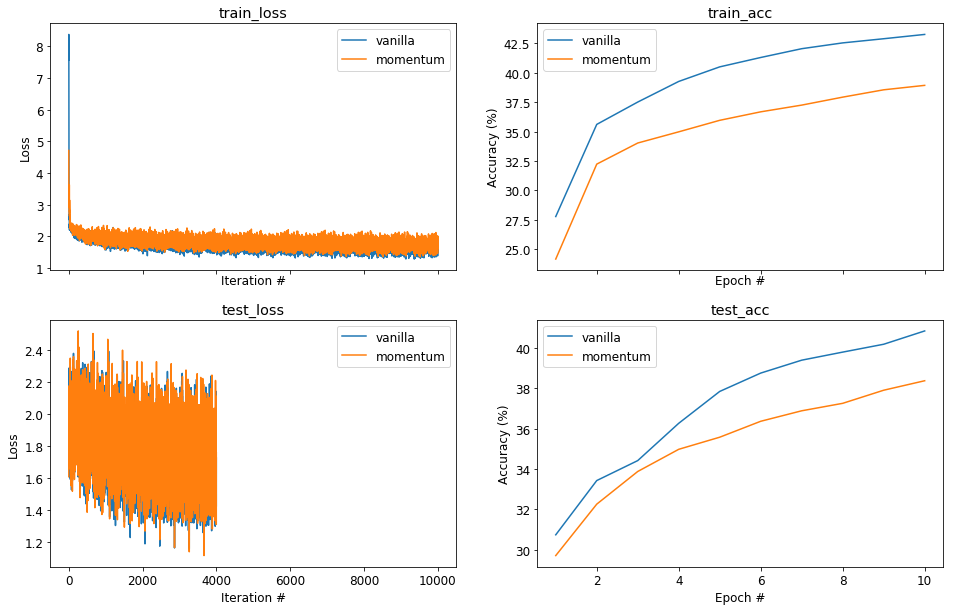

```python
fig_optim = train_with_optimizer('momentum', optimizers.MomentumSGD, fig_optim)
fig_optim
```

## RMSProp

This is another optmizer that accounts for previous gradients, but this time it uses them to adapt the learning rate per parameter.

RMSProp maintains a decaying moving average of previous squared gradients, $$ \vec{r}_{t+1} = \gamma\vec{r}_{t} + (1-\gamma)\delta\vec{\theta}_t^2 $$

where $0<\gamma<1$ is a decay constant usually set close to $1$. The update rule for each parameter is then, $$ \vec{\theta}_{t+1} = \vec{\theta}_t - \left( \frac{\eta}{\sqrt{r_{t+1}+\varepsilon}} \right) \delta\vec{\theta}_t $$

where $\varepsilon$ is a small constant to prevent numerical instability. The idea here is to decrease the learning rate for parameters with high gradient values and vice-versa. The decaying moving average prevents accumulating all the past gradients which would cause the effective learning rate to become zero.

**TODO**:

1. Complete the implementation of the `RMSProp` class in the `hw2/optimizers.py` module.
2. Tweak the learning rate for RMSProp in `part2_optim_hp()` the function in the `hw2/answers.py` module.
3. Run the following block to compare to the other optimizers.

```
--- EPOCH 1/10 ---
train_batch (Avg. Loss 2.532, Accuracy 13.1): 100%|██████████| 1000/1000 [00:23<00:00, 42.23it/s]
test_batch (Avg. Loss 2.273, Accuracy 16.4): 100%|██████████| 400/400 [00:03<00:00, 113.02it/s]
--- EPOCH 2/10 ---
train_batch (Avg. Loss 2.186, Accuracy 19.7): 100%|██████████| 1000/1000 [00:22<00:00, 45.02it/s]
test_batch (Avg. Loss 2.132, Accuracy 21.1): 100%|██████████| 400/400 [00:03<00:00, 117.69it/s]
--- EPOCH 3/10 ---
train_batch (Avg. Loss 2.078, Accuracy 23.5): 100%|██████████| 1000/1000 [00:23<00:00, 42.65it/s]
test_batch (Avg. Loss 2.049, Accuracy 24.4): 100%|██████████| 400/400 [00:03<00:00, 113.41it/s]
--- EPOCH 4/10 ---
train_batch (Avg. Loss 2.014, Accuracy 26.6): 100%|██████████| 1000/1000 [00:23<00:00, 41.62it/s]
test_batch (Avg. Loss 1.995, Accuracy 27.4): 100%|██████████| 400/400 [00:03<00:00, 114.98it/s]
--- EPOCH 5/10 ---
train_batch (Avg. Loss 1.969, Accuracy 29.1): 100%|██████████| 1000/1000 [00:23<00:00, 42.23it/s]
test_batch (Avg. Loss 1.955, Accuracy 29.3): 100%|██████████| 400/400 [00:03<00:00, 111.78it/s]
--- EPOCH 6/10 ---
train_batch (Avg. Loss 1.935, Accuracy 30.9): 100%|██████████| 1000/1000 [00:23<00:00, 43.25it/s]
test_batch (Avg. Loss 1.925, Accuracy 30.6): 100%|██████████| 400/400 [00:03<00:00, 113.22it/s]
--- EPOCH 7/10 ---
train_batch (Avg. Loss 1.909, Accuracy 31.9): 100%|██████████| 1000/1000 [00:23<00:00, 43.99it/s]
test_batch (Avg. Loss 1.902, Accuracy 31.9): 100%|██████████| 400/400 [00:03<00:00, 115.46it/s]
--- EPOCH 8/10 ---
train_batch (Avg. Loss 1.888, Accuracy 32.6): 100%|██████████| 1000/1000 [00:22<00:00, 42.25it/s]
test_batch (Avg. Loss 1.884, Accuracy 32.4): 100%|██████████| 400/400 [00:03<00:00, 114.57it/s]
--- EPOCH 9/10 ---
train_batch (Avg. Loss 1.872, Accuracy 33.3): 100%|██████████| 1000/1000 [00:22<00:00, 45.21it/s]
test_batch (Avg. Loss 1.870, Accuracy 33.2): 100%|██████████| 400/400 [00:03<00:00, 113.70it/s]
--- EPOCH 10/10 ---
train_batch (Avg. Loss 1.858, Accuracy 33.8): 100%|██████████| 1000/1000 [00:23<00:00, 44.35it/s]
test_batch (Avg. Loss 1.859, Accuracy 33.5): 100%|██████████| 400/400 [00:03<00:00, 110.92it/s]
```

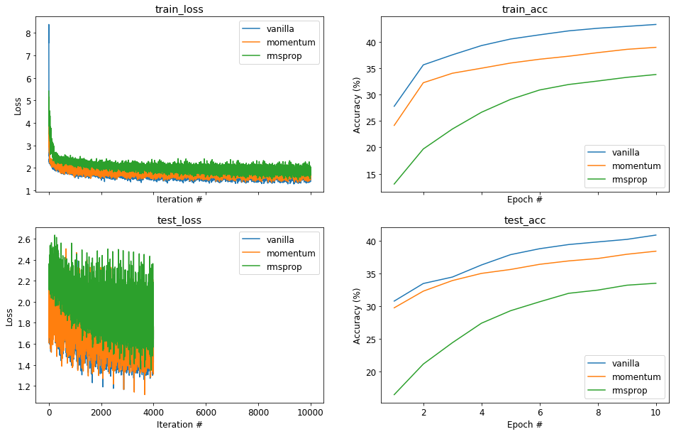

```python
fig_optim = train_with_optimizer('rmsprop', optimizers.RMSProp, fig_optim)
fig_optim
```

## Dropout Regularization

[Dropout](http://jmlr.org/papers/volume15/srivastava14a.old/srivastava14a.pdf) is a useful technique to improve generalization of deep models.

There are a few important things to note about dropout:

**TODO**: Complete the implementation of the `Dropout` class in the `hw2/blocks.py` module.

```python
from hw2.grad_compare import compare_block_to_torch

# Check architecture of MLP with dropout layers
mlp_dropout = models.MLP(in_features, num_classes, [50]*3, dropout=0.5)
print(mlp_dropout)
test.assertEqual(len(mlp_dropout.sequence), 10)
for b1, b2 in zip(mlp_dropout.sequence, mlp_dropout.sequence[1:]):
    if isinstance(b1, blocks.ReLU):
        test.assertIsInstance(b2, blocks.Dropout)
test.assertIsInstance(mlp_dropout.sequence[-1], blocks.Linear)

# Test end-to-end gradient in train and test modes.
mlp_dropout.train(True)
for diff in compare_block_to_torch(mlp_dropout, torch.randn(500, in_features)):
    test.assertLess(diff, 1e-2)

mlp_dropout.train(False)
for diff in compare_block_to_torch(mlp_dropout, torch.randn(500, in_features)):
    test.assertLess(diff, 1e-2)
```

```
MLP, Sequential
	[0] Linear(3072, 50)
	[1] ReLU
	[2] Dropout(p=0.5)
	[3] Linear(50, 50)
	[4] ReLU
	[5] Dropout(p=0.5)
	[6] Linear(50, 50)
	[7] ReLU
	[8] Dropout(p=0.5)
	[9] Linear(50, 10)

Comparing gradients...
input    diff=0.000
param#01 diff=0.000
param#02 diff=0.000
param#03 diff=0.000
param#04 diff=0.000
param#05 diff=0.000
param#06 diff=0.000
param#07 diff=0.000
param#08 diff=0.000
Comparing gradients...
input    diff=0.000
param#01 diff=0.000
param#02 diff=0.000
param#03 diff=0.000
param#04 diff=0.000
param#05 diff=0.000
param#06 diff=0.000
param#07 diff=0.000
param#08 diff=0.000
```

To see whether dropout really improves generalization, let's take a small training set (small enough to overfit) and a large test set and check whether we get less overfitting and perhaps improved test-set accuracy when using dropout.

```python
# Define a small set from CIFAR-10, but take a larger test set since we want to test generalization
batch_size = 30
max_batches = 40
in_features = 3*32*32
num_classes = 10
dl_train = torch.utils.data.DataLoader(ds_train, batch_size, shuffle=False)
dl_test = torch.utils.data.DataLoader(ds_test, batch_size*2, shuffle=False)
```

```python
# Get hyperparameters
hp = answers.part2_dropout_hp()
hidden_features = [400] * 1
num_epochs = 30
```

**TODO**: Tweak the hyperparameters for this section in the `part2_dropout_hp()` function in the `hw2/answers.py` module. Try to set them so that the first model (with `dropout`=0) overfits. You can disable the other dropout options until you tune the hyperparameters. We can then see the effect of dropout for generalization.

```
*** Training with dropout= 0
--- EPOCH 1/30 ---
train_batch (Avg. Loss 2.755, Accuracy 16.6): 100%|██████████| 1667/1667 [00:31<00:00, 53.69it/s]
test_batch (Avg. Loss 2.444, Accuracy 20.6): 100%|██████████| 167/167 [00:02<00:00, 61.10it/s]
--- EPOCH 7/30 ---
train_batch (Avg. Loss 2.043, Accuracy 29.8): 100%|██████████| 1667/1667 [00:30<00:00, 55.14it/s]
test_batch (Avg. Loss 2.037, Accuracy 30.1): 100%|██████████| 167/167 [00:02<00:00, 63.13it/s]
--- EPOCH 13/30 ---
train_batch (Avg. Loss 1.939, Accuracy 32.8): 100%|██████████| 1667/1667 [00:30<00:00, 55.04it/s]
test_batch (Avg. Loss 1.938, Accuracy 32.6): 100%|██████████| 167/167 [00:02<00:00, 61.63it/s]
--- EPOCH 19/30 ---
train_batch (Avg. Loss 1.883, Accuracy 34.6): 100%|██████████| 1667/1667 [00:30<00:00, 54.11it/s]
test_batch (Avg. Loss 1.884, Accuracy 34.4): 100%|██████████| 167/167 [00:02<00:00, 62.51it/s]
--- EPOCH 25/30 ---
train_batch (Avg. Loss 1.845, Accuracy 35.9): 100%|██████████| 1667/1667 [00:30<00:00, 54.33it/s]
test_batch (Avg. Loss 1.847, Accuracy 35.6): 100%|██████████| 167/167 [00:02<00:00, 61.43it/s]
--- EPOCH 30/30 ---
train_batch (Avg. Loss 1.820, Accuracy 36.7): 100%|██████████| 1667/1667 [00:30<00:00, 54.61it/s]
test_batch (Avg. Loss 1.824, Accuracy 36.4): 100%|██████████| 167/167 [00:02<00:00, 62.28it/s]
*** Training with dropout= 0.4
--- EPOCH 1/30 ---
train_batch (Avg. Loss 3.594, Accuracy 12.1): 100%|██████████| 1667/1667 [00:30<00:00, 54.43it/s]
test_batch (Avg. Loss 2.674, Accuracy 20.0): 100%|██████████| 167/167 [00:02<00:00, 61.57it/s]
--- EPOCH 7/30 ---
train_batch (Avg. Loss 2.200, Accuracy 20.5): 100%|██████████| 1667/1667 [00:31<00:00, 52.12it/s]
test_batch (Avg. Loss 2.173, Accuracy 25.4): 100%|██████████| 167/167 [00:02<00:00, 59.92it/s]
--- EPOCH 13/30 ---
train_batch (Avg. Loss 2.141, Accuracy 23.0): 100%|██████████| 1667/1667 [00:33<00:00, 50.34it/s]
test_batch (Avg. Loss 2.121, Accuracy 26.4): 100%|██████████| 167/167 [00:02<00:00, 55.96it/s]
--- EPOCH 19/30 ---
train_batch (Avg. Loss 2.130, Accuracy 23.9): 100%|██████████| 1667/1667 [00:33<00:00, 45.78it/s]
test_batch (Avg. Loss 2.117, Accuracy 27.0): 100%|██████████| 167/167 [00:03<00:00, 55.52it/s]
--- EPOCH 25/30 ---
train_batch (Avg. Loss 2.124, Accuracy 24.4): 100%|██████████| 1667/1667 [00:32<00:00, 51.08it/s]
test_batch (Avg. Loss 2.127, Accuracy 27.0): 100%|██████████| 167/167 [00:02<00:00, 58.75it/s]
--- EPOCH 30/30 ---
train_batch (Avg. Loss 2.125, Accuracy 24.4): 100%|██████████| 1667/1667 [00:32<00:00, 51.30it/s]
test_batch (Avg. Loss 2.134, Accuracy 27.5): 100%|██████████| 167/167 [00:03<00:00, 55.22it/s]
*** Training with dropout= 0.8
--- EPOCH 1/30 ---
train_batch (Avg. Loss 3.316, Accuracy 14.3): 100%|██████████| 1667/1667 [00:31<00:00, 53.48it/s]
test_batch (Avg. Loss 2.388, Accuracy 22.5): 100%|██████████| 167/167 [00:02<00:00, 62.46it/s]
--- EPOCH 7/30 ---
train_batch (Avg. Loss 2.113, Accuracy 25.6): 100%|██████████| 1667/1667 [00:32<00:00, 52.02it/s]
test_batch (Avg. Loss 2.009, Accuracy 29.1): 100%|██████████| 167/167 [00:02<00:00, 56.60it/s]
--- EPOCH 13/30 ---
train_batch (Avg. Loss 2.015, Accuracy 28.6): 100%|██████████| 1667/1667 [00:32<00:00, 51.23it/s]
test_batch (Avg. Loss 1.954, Accuracy 31.3): 100%|██████████| 167/167 [00:02<00:00, 61.09it/s]
--- EPOCH 19/30 ---
train_batch (Avg. Loss 1.985, Accuracy 30.2): 100%|██████████| 1667/1667 [00:32<00:00, 51.08it/s]
test_batch (Avg. Loss 1.938, Accuracy 31.8): 100%|██████████| 167/167 [00:02<00:00, 56.90it/s]
--- EPOCH 25/30 ---
train_batch (Avg. Loss 1.973, Accuracy 31.0): 100%|██████████| 1667/1667 [00:32<00:00, 51.36it/s]
test_batch (Avg. Loss 1.932, Accuracy 32.4): 100%|██████████| 167/167 [00:02<00:00, 57.34it/s]
--- EPOCH 30/30 ---
train_batch (Avg. Loss 1.965, Accuracy 31.5): 100%|██████████| 1667/1667 [00:32<00:00, 51.25it/s]
test_batch (Avg. Loss 1.930, Accuracy 33.1): 100%|██████████| 167/167 [00:02<00:00, 59.53it/s]
```

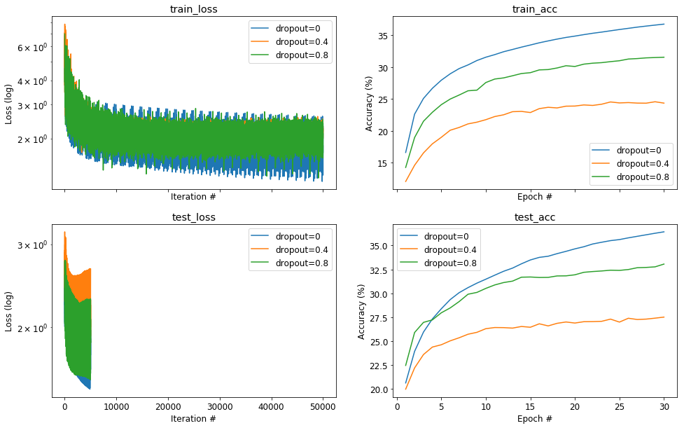

```python
torch.manual_seed(seed)
fig=None
for dropout in [0, 0.4, 0.8]:
    model = models.MLP(in_features, num_classes, hidden_features, wstd=hp['wstd'], dropout=dropout)
    loss_fn = blocks.CrossEntropyLoss()
    optimizer = optimizers.MomentumSGD(model.params(), learn_rate=hp['lr'], reg=0)

    print('*** Training with dropout=', dropout)
    trainer = training.BlocksTrainer(model, loss_fn, optimizer)
    fit_res_dropout = trainer.fit(dl_train, dl_test, num_epochs, max_batches=max_batches, print_every=6)
    fig, axes = plot_fit(fit_res_dropout, fig=fig, legend=f'dropout={dropout}', log_loss=True)
```

## Questions

**TODO** Answer the following questions. Write your answers in the appropriate variables in the module `hw2/answers.py`.

```python
from cs236605.answers import display_answer
import hw2.answers
```

### Question 1

Regarding the graphs you got for the three dropout configurations:

1. Explain the graphs of no-dropout vs dropout. Do they match what you expected to see?
   - If yes, explain why and provide examples based on the graphs.
   - If no, explain what you think the problem is and what should be modified to fix it.
2. Compare the low-dropout setting to the high-dropout setting and explain based on your graphs.

```python
display_answer(hw2.answers.part2_q1)
```

**Your answer:**

The results do not match what we excpact to see. We would expact to see better results using droupout in opposed to no dropout but from our results we can see that it is not the case. We think the reason is that with dropout the model trains slower since we randomaly shut down some of the neurons and therefore the training of them will be slower, the upside of this technic is that we get a model with redundancy and that should yield better results. we think that if we would test the output of the models after more epoches we would see this happening, but 30 epoches are not enough for this to happen.

### Question 2

When training a model with the cross-entropy loss function, is it possible for the test loss to **increase** for a few epochs while the test accuracy also **increases**?

If it's possible explain how, if it's not explain why not.

```python
display_answer(hw2.answers.part2_q2)
```

It is possible because there is no direct relation between the accuracy and the total loss. The accurecy is dependent only on the class with the best score while the toal loss is the mean of the loss function for each class. That means that we can have a situation where we find more classes that are correct (i.e. the best score is for the correct class) but for the classes the are not correct the values of the loss function increase. therefore we will get a higher accuracy and in addition higher total loss.